# Whether a given credit card transaction will be fraudulent or not?

Marjan Rezvani

Fall 2020

## Introduction

#### Banking Fraud has been an ever-growing issue with huge consequences to banks and customers, in terms of financial losses, trust and credibility. An effective fraud detection system should be able to detect fraudulent transactions with high accuracy and efficiency.

#### A major challenge in applying a model to fraud detection is presence of highly imbalanced data sets. In many available datasets, majority of transactions are genuine with an extremely small percentage of fraudulent ones. Designing an accurate and efficient fraud detection system that is low on false positives but detects fraudulent activity effectively is a significant challenge.

#### In this project, I have applied multiple binary classification approaches such as Logistic Regression, Random Forest and Support Vector Machine to solve this problem on a labeled dataset. my models collect information, analyze the data gathered and extract the required features. my goal is to build binary classifiers which are able to separate fraud transactions from non-fraud transactions. Then I compared the effectiveness of these approaches in detecting fraud transactions.

## Related Work

#### There are different types of approaches which have been applied to the problem of fraud detection which gave me some ideas to do my project. Different computational methods have been stated for detecting the fraud by computing various parameters for each kind of algorithm. and They had taken the different datasets german credit card dataset.

#### For instance, in paper https://ijarcce.com/upload/2017/june-17/IJARCCE%202.pdf there have been used some of the supervised algorithms to detect the fraud which gives accurate results. first They have explained different types of frauds which are: credit card fraud, financial fraud, mortgage fraud, insurance fraud , telecommunication fraud. Then they used some supervised learning algorithms predictions which are made on the known training dataset. Their learning algorithms are further grouped into regression and classification problems. so they collected the accurate training dataset and then have found the accuracy of the function. It is the machine learning task of inferring a function from supervised training data. in continue, they created small decision trees so that records can be identified after only a few decision tree splitting. then tried to match a hoped for minimalism of the process of decision making.

#### In the other paper, https://arxiv.org/pdf/1611.06439.pdf, some people investigated difficulties of credit card fraud detection. Then the advantages and disadvantages of fraud detection methods have been enumerated and compared.Furthermore, they have presented a classification of some techniques into two main fraud detection approaches, namely, misuses (supervised) and anomaly detection (unsupervised).

#### In addition, a group of students in their project http://cs229.stanford.edu/proj2018/report/261.pdf have reviewed and compared such multiple state of the techniques, datasets and evaluation criteria applied to this problem. they have applied multiple binary classification approaches - Logistic regression, Linear SVM and SVM with RBF kernel on a labeled dataset.

## Dataset and Explanatory Analysis

#### In this project I have used a dataset downloaded from capital one data science challenge repository https://github.com/CapitalOneRecruiting/DS which contains a year credit card transaction made in 2016. There are 641914 instances in the dataset. As it’s shown below:

```r
raw_data <- read.csv(file='/Users/marjanrezvani/Documents/Fall2020/eco_stat/final_project/data/rawdata.csv')
colnames(raw_data)[order(colnames(raw_data))]
```

```
##  [1] "accountNumber"            "accountOpenDate"
##  [3] "acqCountry"               "availableMoney"
##  [5] "cardCVV"                  "cardLast4Digits"
##  [7] "cardPresent"              "creditLimit"
##  [9] "currentBalance"           "currentExpDate"
## [11] "customerId"               "dateOfLastAddressChange"
## [13] "echoBuffer"               "enteredCVV"
## [15] "expirationDateKeyInMatch" "isFraud"
## [17] "merchantCategoryCode"     "merchantCity"
## [19] "merchantCountryCode"      "merchantName"
## [21] "merchantState"            "merchantZip"
## [23] "posConditionCode"         "posEntryMode"
## [25] "posOnPremises"            "recurringAuthInd"
## [27] "transactionAmount"        "transactionDateTime"
## [29] "transactionType"          "X"
```

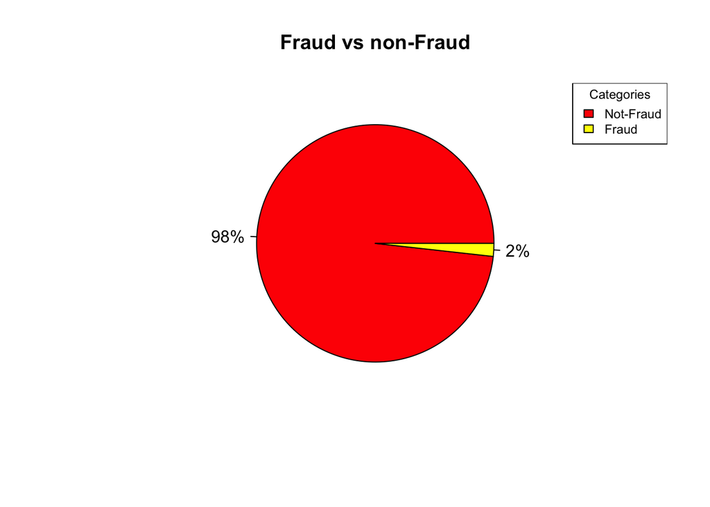

```r
pie(table(raw_data$isFraud),
    labels = paste(round(prop.table(table(raw_data$isFraud))*100), "%", sep = ""),
    col = heat.colors(2), main = "Fraud vs non-Fraud")

legend("topright", legend = c("Not-Fraud", "Fraud"),
       fill = heat.colors(2), title = "Categories", cex = 0.75)
```

#### Classification results for the unbalanced data could be misleading. So, I first make a balanced dataset. There are various ways to make data balanced. such as downsample majority class or upsample minority class. In this part, I downsample majority class.

```r
dim(raw_data[raw_data$isFraud=='True',])[1] # Fraud
```

```
## [1] 11302
```

```r
dim(raw_data[raw_data$isFraud=='False',])[1] # non Fraud
```

```
## [1] 630612
```

```r
df1 = raw_data[raw_data$isFraud=='True',]
tmp = raw_data[raw_data$isFraud=='False',]
df2 = tmp[sample(nrow(raw_data[raw_data$isFraud=='False',]),15000),]

balanced_df = rbind(df1,df2)
```

#### then I created a new variable named ‘correctCVV’. Its value is True if cardCVV matches enteredCVV

```r
balanced_df$correctCVV <- with(balanced_df, ifelse(cardCVV==enteredCVV, 'True', 'False'))

summary(balanced_df)
```

```
##        X          accountNumber         accountOpenDate  acqCountry
##  Min.   :     0   Min.   :100547107   2015-12-11:  545      :  226
##  1st Qu.:164422   1st Qu.:318001076   2014-06-06:  375   CAN:  105
##  Median :322830   Median :534398540   2013-07-04:  281   MEX:  109
##  Mean   :323332   Mean   :548673942   2012-10-05:  261   PR :   62
##  3rd Qu.:486389   3rd Qu.:782969776   2014-01-31:  209   US :25800
##  Max.   :641883   Max.   :999985343   2015-09-24:  208
##                                       (Other)   :24423
##  availableMoney       cardCVV      cardLast4Digits cardPresent
##  Min.   : -894.6   Min.   :100.0   Min.   :   0    False:14696
##  1st Qu.: 1184.0   1st Qu.:324.0   1st Qu.:2281    True :11606
##  Median : 3631.5   Median :566.0   Median :4743
##  Mean   : 6674.4   Mean   :549.6   Mean   :4806
##  3rd Qu.: 8131.8   3rd Qu.:755.0   3rd Qu.:7224
##  Max.   :50000.0   Max.   :998.0   Max.   :9998
##
##   creditLimit    currentBalance    currentExpDate    customerId
##  Min.   :  250   Min.   :    0.0   12/2021:  213   Min.   :100547107
##  1st Qu.: 5000   1st Qu.:  581.1   05/2025:  192   1st Qu.:318001076
##  Median : 7500   Median : 2299.9   08/2025:  191   Median :534398540
##  Mean   :10944   Mean   : 4269.4   08/2026:  188   Mean   :548673942
##  3rd Qu.:15000   3rd Qu.: 5326.4   11/2029:  187   3rd Qu.:782969776
##  Max.   :50000   Max.   :47490.7   12/2022:  187   Max.   :999985343
##                                    (Other):25144
##  dateOfLastAddressChange echoBuffer       enteredCVV
##  2016-01-29:  306        Mode:logical   Min.   :  2.0
##  2016-05-11:  154        NA's:26302     1st Qu.:324.0
##  2016-01-26:  151                       Median :566.0
##  2016-03-15:  144                       Mean   :549.2
##  2016-04-25:  144                       3rd Qu.:754.0
##  2016-03-10:  136                       Max.   :998.0
##  (Other)   :25267
##  expirationDateKeyInMatch  isFraud         merchantCategoryCode merchantCity
##  False:26274              False:15000   online_retail:7415      Mode:logical
##  True :   28              True :11302   fastfood     :4095      NA's:26302
##                                         food         :2938
##                                         entertainment:2523
##                                         rideshare    :2286
##                                         online_gifts :1407
##                                         (Other)      :5638
```

[output cut: 17 more lines]

```
##  Min.   :   0.00   2016-01-11T11:37:53:    2                        :   26
##  1st Qu.:  48.27   2016-01-11T11:42:40:    2    ADDRESS_VERIFICATION:  484
##  Median : 124.38   2016-03-20T14:33:51:    2    PURCHASE            :25119
##  Mean   : 175.52   2016-04-29T13:56:53:    2    REVERSAL            :  673
##  3rd Qu.: 248.54   2016-06-01T11:44:19:    2
##  Max.   :1743.51   2016-06-24T11:59:15:    2
##                    (Other)            :26290
##   correctCVV
##  Length:26302
##  Class :character
##  Mode  :character
##
##
##
##
```

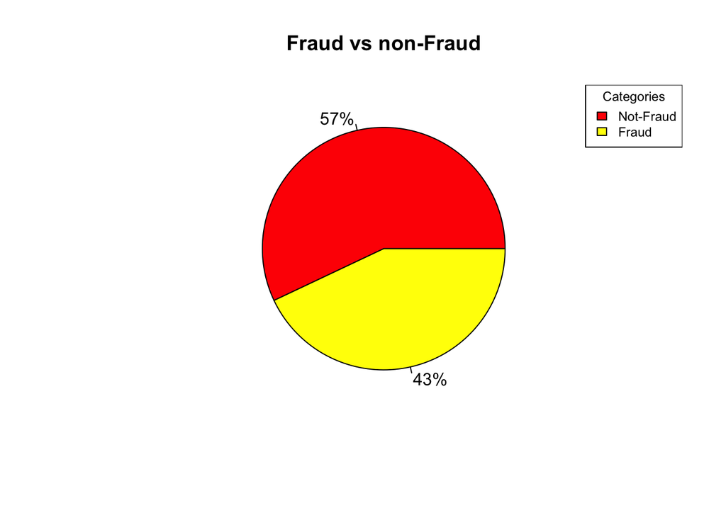

```r
attach(balanced_df)

pie(table(isFraud), labels = paste(round(prop.table(table(isFraud))*100), "%", sep = ""),
    col = heat.colors(2), main = "Fraud vs non-Fraud")

legend("topright", legend = c("Not-Fraud", "Fraud"),
       fill = heat.colors(2), title = "Categories", cex = 0.75)
```

#### So now from the pie chart we observe that we have kind of balanced dataset.

#### Let’s do some plots to examine the dataset.

#### First thing I am interested in is to explore and see if there is a difference between the distribution of transactionamount across Fraud or non-Fraud.

#### Plot below shows that Fradualant transavctions have higher transaction amount (e.g. compare the area under the curve for range of $500 to $1000 )

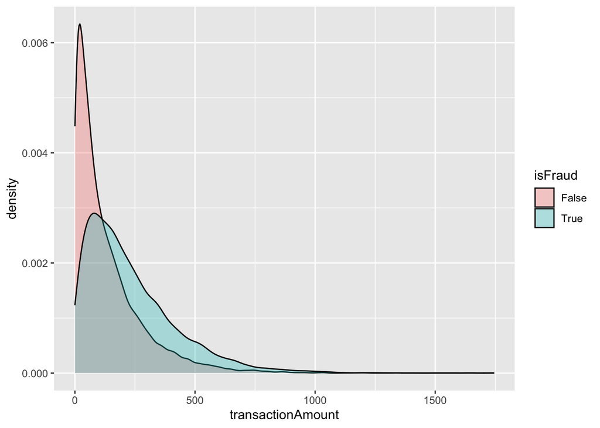

```r
library(ggplot2)
ggplot(data=balanced_df, aes(x = transactionAmount, fill = isFraud)) +
  geom_density(alpha = .3) #alpha used for filling the density
```

#### Let’s see if how the transactions are distributed across different merchants.

#### Plot below shows that majority of the transactions are from online_retail. fastfood, and food, and entertainment are the other 3 merchants with high number of transactions.

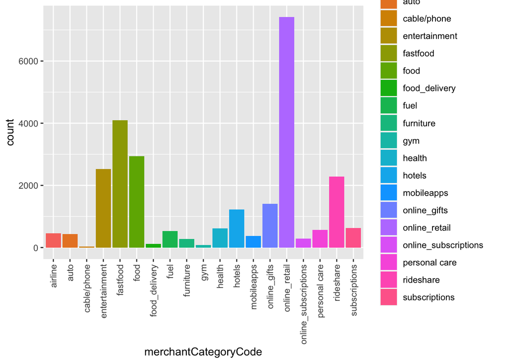

```r
(ggplot(balanced_df, aes(x=merchantCategoryCode, fill=merchantCategoryCode))
  + geom_bar()
  + theme(axis.text.x = element_text(angle = 90, vjust = 0.5, hjust=1))
)
```

#### Another interesting feature is ‘expirationDateKeyInMatch’ which shows whether the entered expiration date matched the one on the card.

#### Plot below shows that for fradulent transactions, majority of them expiration date does not match

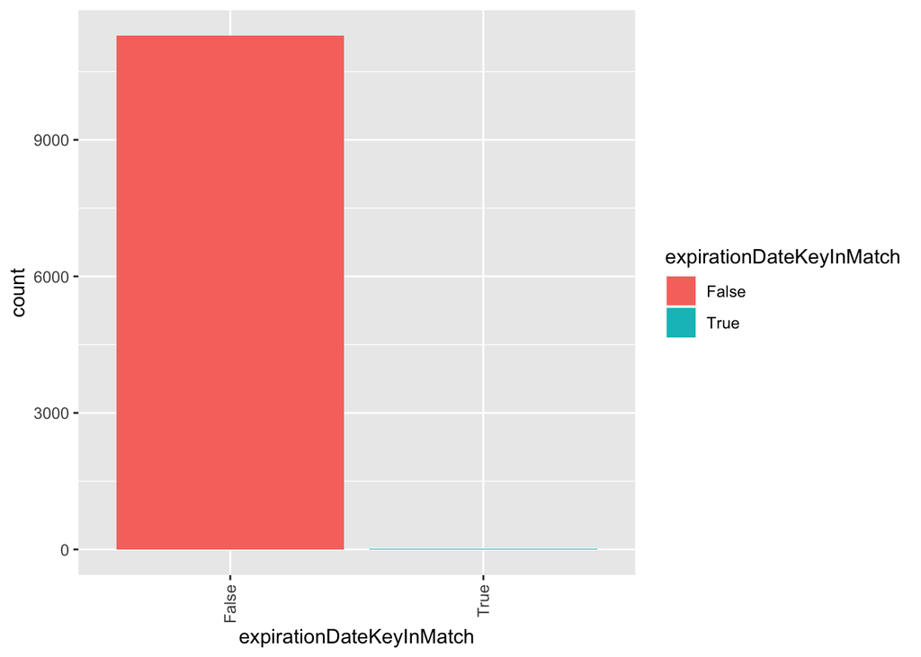

```r
(ggplot(balanced_df[balanced_df$isFraud=='True',], aes(x=expirationDateKeyInMatch, fill=expirationDateKeyInMatch))
  + geom_bar()
  + theme(axis.text.x = element_text(angle = 90, vjust = 0.5, hjust=1))
)
```

#### Similarly, we can look at cardPresent featute. It tells whether card was present during transaction or not. Plot below indicates that for Fradulent transactions, most of the transactioins card was not present (in other words most of them was online. Actually, we can confirm this by looking at distribution of Fradulent transactions across different merchants)

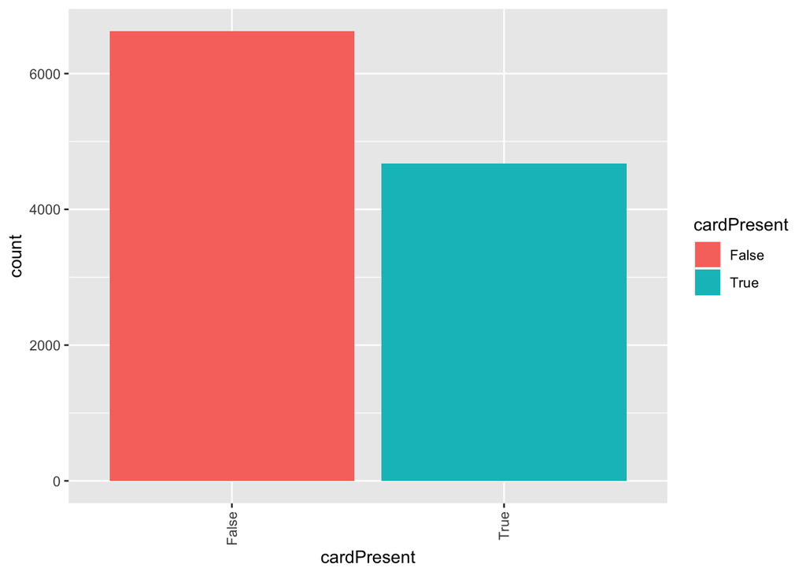

```r
(ggplot(balanced_df[balanced_df$isFraud=='True',], aes(x=cardPresent, fill=cardPresent))
 + geom_bar()
 + theme(axis.text.x = element_text(angle = 90, vjust = 0.5, hjust=1))
)
```

#### And Finally plot below shows that, we have most of the Fradulent transactions heppening in online_retails.

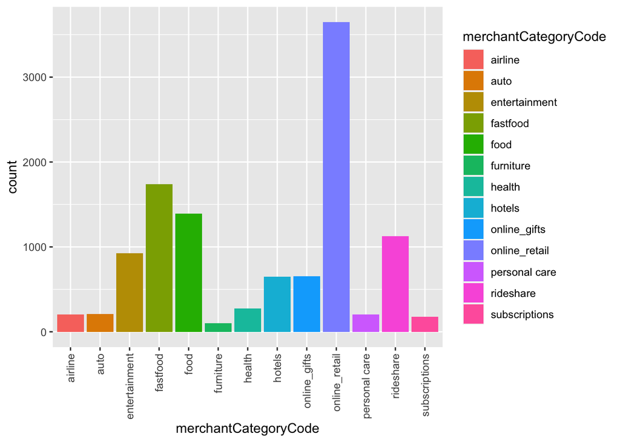

```r
(ggplot(balanced_df[balanced_df$isFraud=='True',], aes(x=merchantCategoryCode, fill=merchantCategoryCode))
  + geom_bar()
  + theme(axis.text.x = element_text(angle = 90, vjust = 0.5, hjust=1))
)
```

## Methods

#### my goal is to detect fraud and non-fraud transactions by building appropriate binary classifiers. I have built some models using logistic regression, Random Forest and Support Vector machine. then I compare the effectiveness of these approaches in detecting fraud transactions.

#### With these models, my goal is to (1) learn a model that, given the features, can predict which transactions have this label, (2) evaluate the model and estimate its generalizable accuracy metric, and (3) identify the features most important for prediction.

#### then to be able to test the performance of my algorithms, I split data into train test split by the ration of 0.25 and feed into model. Then I discuss results obtained in training, validation and testing phases. and evaluate performance of my models by computing accuracy metrics.

```r
balanced_df$merchantCategoryCode <- as.factor(balanced_df$merchantCategoryCode)
balanced_df$transactionType <- as.factor(balanced_df$transactionType)
balanced_df$correctCVV <- as.factor(balanced_df$correctCVV)
balanced_df$cardPresent <- as.factor(balanced_df$cardPresent)

## 75% of the sample size
smp_size <- floor(0.75 * nrow(balanced_df))

## set the seed to make the partition reproducible
set.seed(123)
train_ind <- sample(seq_len(nrow(balanced_df)), size = smp_size)

train <- balanced_df[train_ind, ]
test <- balanced_df[-train_ind, ]

vartokeep <- c('isFraud','transactionAmount','merchantCategoryCode','transactionType',
               'correctCVV', 'cardPresent', 'currentBalance', 'creditLimit')
train <- train[,vartokeep]
test <- test[,vartokeep]
```

### Logistic Regression

#### I fit my logistic regression model to my data and get the following classification report and confusion matrix. The number of correct and incorrect predictions are summarized with count values and broken down by each class ‘Fraud’ and ‘Not Fraud’.

```r
model_logit <- glm(isFraud ~ transactionAmount + merchantCategoryCode + transactionType+
                     correctCVV + cardPresent + currentBalance + creditLimit,
                    family = binomial, data = train)

summary(model_logit)
```

```
##
## Call:
## glm(formula = isFraud ~ transactionAmount + merchantCategoryCode +
##     transactionType + correctCVV + cardPresent + currentBalance +
##     creditLimit, family = binomial, data = train)
##
## Deviance Residuals:
##     Min       1Q   Median       3Q      Max
## -2.8445  -1.0068  -0.6414   1.1656   2.1357
##
## Coefficients:
##                                            Estimate Std. Error z value Pr(>|z|)
## (Intercept)                               8.200e-02  5.073e-01   0.162   0.8716
## transactionAmount                         3.204e-03  1.008e-04  31.795  < 2e-16
## merchantCategoryCodeauto                  7.869e-01  1.752e-01   4.492 7.06e-06
## merchantCategoryCodecable/phone          -1.616e+01  4.762e+02  -0.034   0.9729
## merchantCategoryCodeentertainment         1.328e-01  1.412e-01   0.941   0.3467
## merchantCategoryCodefastfood              4.425e-01  1.402e-01   3.156   0.0016
## merchantCategoryCodefood                  6.582e-01  1.424e-01   4.620 3.83e-06
## merchantCategoryCodefood_delivery        -1.605e+01  2.632e+02  -0.061   0.9514
## merchantCategoryCodefuel                 -1.542e+01  1.209e+02  -0.128   0.8985
## merchantCategoryCodefurniture             1.004e-01  2.039e-01   0.492   0.6225
## merchantCategoryCodegym                  -1.592e+01  3.041e+02  -0.052   0.9583
## merchantCategoryCodehealth               -3.966e-02  1.519e-01  -0.261   0.7940
## merchantCategoryCodehotels                7.838e-01  1.458e-01   5.376 7.63e-08
## merchantCategoryCodemobileapps           -1.589e+01  1.421e+02  -0.112   0.9110
## merchantCategoryCodeonline_gifts          1.625e-02  1.322e-01   0.123   0.9022
## merchantCategoryCodeonline_retail         4.264e-02  1.197e-01   0.356   0.7217
## merchantCategoryCodeonline_subscriptions -1.594e+01  1.606e+02  -0.099   0.9209
## merchantCategoryCodepersonal care         1.409e-01  1.713e-01   0.823   0.4108
## merchantCategoryCoderideshare             4.657e-02  1.267e-01   0.368   0.7131
## merchantCategoryCodesubscriptions        -8.503e-01  1.610e-01  -5.280 1.29e-07
## transactionTypeADDRESS_VERIFICATION      -1.137e+00  4.974e-01  -2.285   0.0223
## transactionTypePURCHASE                   1.377e-01  4.738e-01   0.291   0.7714
## transactionTypeREVERSAL                   6.317e-02  4.829e-01   0.131   0.8959
## correctCVVTrue                           -8.958e-01  1.477e-01  -6.067 1.31e-09
## cardPresentTrue                          -6.488e-01  7.618e-02  -8.517  < 2e-16
## currentBalance                            1.825e-06  3.176e-06   0.575   0.5654
## creditLimit                              -1.950e-06  1.735e-06  -1.124   0.2611
##
```

[output cut: 22 more lines]

```
## transactionTypeREVERSAL
## correctCVVTrue                           ***
## cardPresentTrue                          ***
## currentBalance
## creditLimit
## ---
## Signif. codes:  0 '***' 0.001 '**' 0.01 '*' 0.05 '.' 0.1 ' ' 1
##
## (Dispersion parameter for binomial family taken to be 1)
##
##     Null deviance: 26949  on 19725  degrees of freedom
## Residual deviance: 24038  on 19699  degrees of freedom
## AIC: 24092
##
## Number of Fisher Scoring iterations: 15
```

```r
logit.pred <- predict(model_logit, test)
logit.pred_label <- (logit.pred > 0.5)

logitpredtable <- table(pred = logit.pred_label, true = test$isFraud)
logitpredtable
```

```
##        true
## pred    False True
##   FALSE  3483 2254
##   TRUE    257  582
```

```r
accuracy.logit <- sum((prop.table(logitpredtable)[1,1])+(prop.table(logitpredtable)[2,2]))
print(accuracy.logit)
```

```
## [1] 0.6181569
```

## Random Forest

```r
require('randomForest')
set.seed(54321)
model_randFor <- randomForest( as.factor(isFraud) ~ transactionAmount + merchantCategoryCode +
                                 transactionType + correctCVV +
                                 cardPresent + currentBalance + creditLimit,
                               data = train, importance=TRUE, proximity=TRUE)

print(model_randFor)
```

```
##
## Call:
##  randomForest(formula = as.factor(isFraud) ~ transactionAmount +      merchantCategoryCode + transactionType + correctCVV + cardPresent +      currentBalance + creditLimit, data = train, importance = TRUE,      proximity = TRUE)
##                Type of random forest: classification
##                      Number of trees: 500
## No. of variables tried at each split: 2
##
##         OOB estimate of  error rate: 34.03%
## Confusion matrix:
##       False True class.error
## False  8238 3022   0.2683837
## True   3691 4775   0.4359792
```

```r
round(importance(model_randFor),2)
```

```
##                      False   True MeanDecreaseAccuracy MeanDecreaseGini
## transactionAmount    61.85 124.32               104.95          1835.87
## merchantCategoryCode 42.04   0.97                70.43           710.86
## transactionType       5.37  12.16                15.59            74.63
## correctCVV           18.52  12.24                20.36            34.31
## cardPresent          40.56 -19.09                40.01            68.65
## currentBalance       11.44  11.72                28.09           974.74
## creditLimit           8.63  24.88                42.60           347.03
```

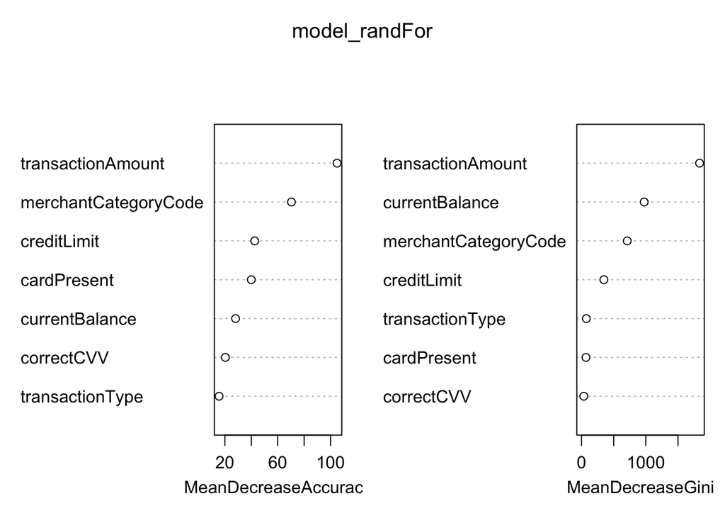

```r
varImpPlot(model_randFor)
```

```r
rf.pred <- predict(model_randFor, test)


RFpredtable <- table(pred = rf.pred, true = test$isFraud)
RFpredtable
```

```
##        true
## pred    False True
##   False  2755 1252
##   True    985 1584
```

```r
accuracy.rf <- sum((prop.table(RFpredtable)[1,1])+(prop.table(RFpredtable)[2,2]))
print(accuracy.rf)
```

```
## [1] 0.6598236
```

## SVM

```r
require(e1071)
svm.model <- svm(as.factor(isFraud) ~ transactionAmount + merchantCategoryCode +
                   transactionType + correctCVV +
                   cardPresent + currentBalance + creditLimit,
                   data = train, cost = 10, gamma = 0.1, probability=TRUE)

svm.pred <- predict(svm.model, test)
SVMpredtable <- table(pred = svm.pred, true = test$isFraud)
SVMpredtable
```

```
##        true
## pred    False True
##   False  2858 1388
##   True    882 1448
```

```r
SVMproppred <- prop.table(SVMpredtable)
SVMproppred
```

```
##        true
## pred        False      True
##   False 0.4346107 0.2110706
##   True  0.1341241 0.2201946
```

```r
SVMgoodpred <- sum((SVMproppred[1,1])+(SVMproppred[2,2]))
SVMgoodpred
```

```
## [1] 0.6548054
```

### Github link : https://github.com/marjanrez/Econometrics-Final-Project

### Bibliography

##### [ftp://ftp.cdc.gov/pub/Health_Statistics/NCHS/Dataset_Documentation/NHIS/2014/personsx_layout.pdf]

##### (ftp://ftp.cdc.gov/pub/Health_Statistics/NCHS/Dataset_Documentation/NHIS/2014/personsx_layout.pdf)

##### http://cs229.stanford.edu/proj2018/report/261.pdf

##### paper https://ieeexplore.ieee.org/abstract/document/1297040

##### http://www.ecmlpkdd2018.org/wp-content/uploads/2018/09/567.pdf